# Twitter Analytics - Arctic Data Center

Last Updated May 2020

## Arctic Data Center Twitter Metrics

I created a Twitter Engagement plan with the hope of increasing the Arctic Data Center’s presence on Twitter. As Twitter has been gaining traction as a tool for both outreach with scientists and not scientists, I thought it would be a good way to better publicize data management and Arctic-focused news, new papers, submitted datasets, and conference participation.

In the era of COVID-19, online engagement is as important as ever, so I’m going to start tracking monthly Twitter metrics to see if what I’m doing is actually making a difference.

# Data Collection - Summary

I collected data manually from https://analytics.twitter.com/user/arcticdatactr/home once a month near the first of each month and added it to the folder Twitter Metrics. This summary file contains:

- month: month of Tweet information
- year: year of Tweet information
- tweets: number of Tweets that month
- profile-visits: Number of times users visited your profile page
- new-followers: Number of new followers you gained (equals gross new followers; does not account for followers lost)
- tweet-impressions: Number of times users are served your tweet in timeline, search results, or from your profile
- mentions: Number of times your @username was mentioned in tweets
- number-followers: Number of followers, manually copied from https://twitter.com/arcticdatactr.
  - Number of followers is the only piece of data in this file that is only available from Twitter at the time you access the site i.e. it is not made available with the rest of the data in this dataset. Thus, there are NAs for dates prior to the time I started to collect this data or for dates before I realized this data was ephemeral.

# Data Collection - Monthly Tweets

I collected tweets from https://analytics.twitter.com/user/arcticdatactr/home once a month near the first of each month and added it to the folder Twitter Metrics. These monthly files contain:

- Tweet-ID: the identifier for the Tweet, which can be used to find the permanent URL
- Tweet-permalink: where to find the Tweet
- Tweet-text: the text (content) of the Tweet
- time: the time the Tweet was sent (GMT)
- impressions: Number of times users are served your tweet in timeline, search results, or from your profile
- engagements:
- engagement-rate:
- retweets: number of times that Tweet was retweeted
- replies: number of replies that Tweet generated
- user-profile-clicks: number of times a user clicked on your profile from that particular tweet
- URL-clicks: number of times that URL within the tweet was clicked
- hashtag-clicks: number of times any of your hashtags were clicked from that tweet
- detail-expands: number of times users clicked ‘see more’ on your tweet
- permalink-clicks:
- follows:
- email-tweet:
- dial-phone:
- media-views:
- media-engagements:

Other metrics that are collected are all about promoted views, etc. which the Arctic Data Center doesn’t use, and as such those were excluded from the analysis.

## Graphing Data - Summary Info

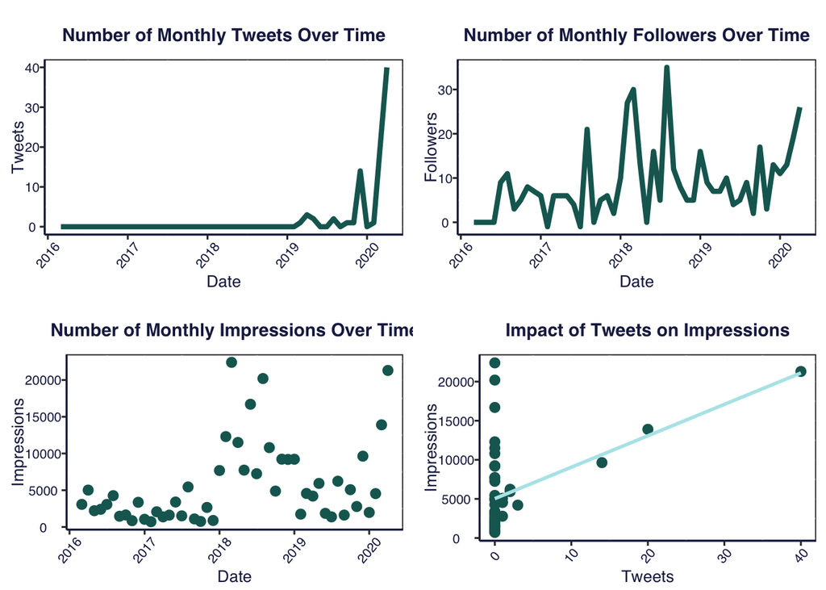

## Data Analysis - Tweet Level Info

### Top 10: Most Liked Tweets

| Tweet | Date and Time | Likes | Retweets | Hashtags Used |
| --- | --- | --- | --- | --- |
| New feature alert! #Arctic #researchers can now create a portal with @arcticdatactr to see #data from across the #catalog all in one place. Each #portal can be branded with logos and colors and has a … | 2020-05-05 16:30:23 | 29 | 10 | c(“Arctic”, “researchers”, “data”, “catalog”, “portal”) |
| Anxiously awaiting the next #dataset highlight? Now it’s live! We’re excited to highlight @rosem36 &amp; her team researching DOC along the Kuparuk River. Learn about the importance of their #data &am… | 2018-04-10 19:11:36 | 21 | 9 | c(“dataset”, “data”, “Arctic”) |
| Reaching out to the biodiversity community with repository management best practices and lessons learned from the Arctic Data Center #digidata @i_steves https://t.co/b9djUYuxiP | 2018-06-04 22:46:53 | 20 | 3 | digidata |
| It’s day two of our #Arctic #datascience training this week @nceas and @sjeanetteclark is leading the dive into @rstudio &amp; #RMarkdown https://t.co/Ni6ZgMvzMc | 2019-01-15 18:31:59 | 15 | 5 | c(“Arctic”, “datascience”, “RMarkdown”) |
| Fittingly, the last day of our #Arctic #datascience training is on #DATAPALOOZA day! We’ve enjoyed learning #dataviz #rstats #github &amp; more #data skills and sharing #opendata sources &amp; best #d… | 2018-08-17 18:43:07 | 14 | 8 | c(“Arctic”, “datascience”, “DATAPALOOZA”, “dataviz”, “rstats”, “github”, “data”, “opendata”, “datamanagement”) |
| This #TidyTuesday, we highlight a new #Rpackage from the #tidyverse team: across()! This makes it easy to perform the same operation on multiple columns with dplyr. #rstats #datascience #opensource ht… | 2020-04-21 17:00:01 | 13 | 6 | c(“TidyTuesday”, “Rpackage”, “tidyverse”, “rstats”, “datascience”, “opensource”) |
| Headed to @POLAR_2018? Join us at our 3 FREE Data Management Workshops during the Open Science Conference! We look forward to meeting you &amp; working to help address your #arctic data needs. From pl… | 2018-06-04 17:00:01 | 13 | 10 | c(“arctic”, “DataScience”, “openscience”, “POLAR2018”) |
| #openaccess #data repositories are a team effort, so it’s fitting that our 5,000th #metadata record comes from the O-Buoy #collaborative team project! Researchers from @UAFGI @BigelowLab @MBARI_News @… | 2018-03-22 18:26:51 | 13 | 8 | c(“openaccess”, “data”, “metadata”, “collaborative”, “Arctic”) |
| You love your #data and we work hard because we love your #data, too! Our team met last week to develop ways to better help you polish, preserve and share your #arctic data effectively and efficiently… | 2018-02-13 18:00:01 | 13 | 0 | c(“data”, “data”, “arctic”, “lovedata18”, “LoveDataWeek”) |
| This #techTuesday, we’re excited to announced that the @arcticdatactr is now @CoreTrustSeal certified. Our established #data preservation practices and infrastructure are now endorsed by an internatio… | 2020-04-14 19:30:00 | 12 | 5 | c(“techTuesday”, “data”) |

### Top 10: Most Retweeted Tweets

| Tweet | Date and Time | Likes | Retweets | Hashtags Used |
| --- | --- | --- | --- | --- |
| Calling all #Arctic researchers: Want to improve your #data management skills &amp; learn ways to implement #DataScience tools in your work? Join us &amp; your arctic colleagues @nceas in August for o… | 2018-03-15 17:27:58 | 12 | 16 | c(“Arctic”, “data”, “DataScience”) |
| We’re hiring! Support the @arcticdatactr and other @nceas projects in building community, supporting Arctic research and promoting open science and data reuse. Community Engagement and Outreach Coordi… | 2019-05-09 18:24:57 | 11 | 15 | NA |
| #Job announcement - The Arctic Data Center and @nceas are looking for Data Fellows! UCSB is an EOE, including disability/vets. https://t.co/CKVhTxldUr | 2020-02-20 23:29:28 | 11 | 11 | Job |
| Calling #Arctic researchers - Do your research data management skills need refreshing? Want to work in a more open, efficient and reproducible way? Apply by August 15th to join our funded Data Science… | 2019-08-01 17:46:23 | 10 | 11 | Arctic |
| Data Science Fellowships available with the @arcticdatactr at @nceas starting July 2018. Apply today: https://t.co/yE5uA8fyQM #datascience #fellowship #arctic | 2018-01-02 22:11:16 | 6 | 11 | c(“datascience”, “fellowship”, “arctic”) |
| Calling #Arctic researchers - Do you want to tackle your research data management skills? Work in a more open, efficient and reproducible way? Apply by April 24th to join our funded Data Science Train… | 2020-03-04 23:58:08 | 4 | 11 | Arctic |
| New feature alert! #Arctic #researchers can now create a portal with @arcticdatactr to see #data from across the #catalog all in one place. Each #portal can be branded with logos and colors and has a … | 2020-05-05 16:30:23 | 29 | 10 | c(“Arctic”, “researchers”, “data”, “catalog”, “portal”) |
| Headed to @POLAR_2018? Join us at our 3 FREE Data Management Workshops during the Open Science Conference! We look forward to meeting you &amp; working to help address your #arctic data needs. From pl… | 2018-06-04 17:00:01 | 13 | 10 | c(“arctic”, “DataScience”, “openscience”, “POLAR2018”) |
| Data #provenance tracks #data processing history, ensuring data can be accurately #reproduced &amp; #interpreted. Easily include it directly in your #arctic data upload. And check back Thurs for a ste… | 2018-02-27 18:00:03 | 5 | 10 | c(“provenance”, “data”, “reproduced”, “interpreted”, “arctic”, “provenance”) |
| Join us at the @arcticdatactr as a paid #datascience fellow. Apps due 2/1 https://t.co/v6Srf0ri8m https://t.co/JwYyLjcqJv | 2017-11-07 17:20:57 | 1 | 10 | datascience |

### Distribution of replies, retweets, and organic tweets

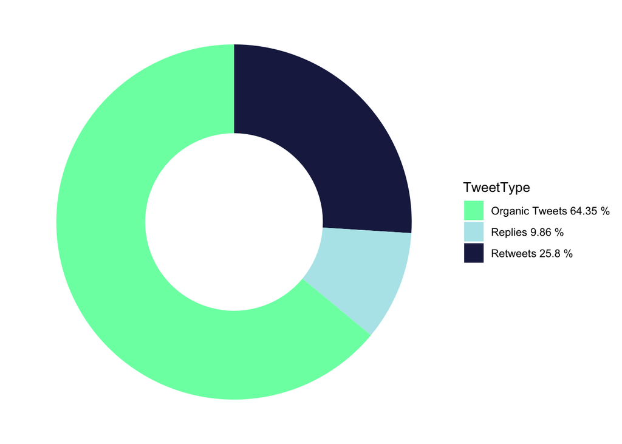

## Analyzing text of tweets

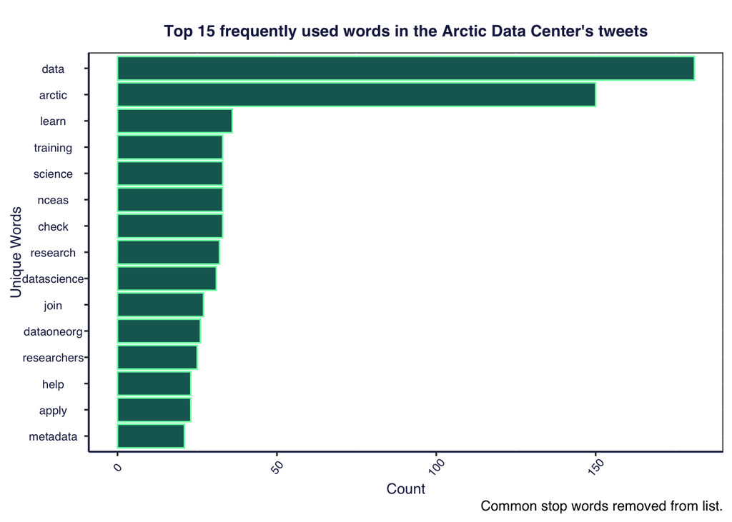

## Using tidytext, tm, and quanteda to make some cute wordclouds and plots

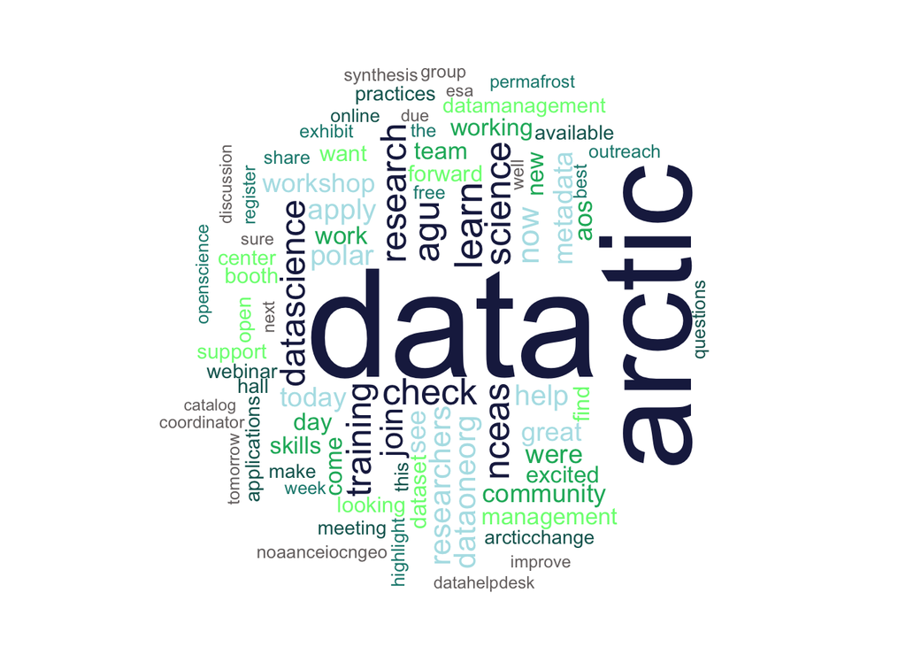

[interactive chart not shown]

# Using tidy text to look for correlations within Arctic Data Center tweets

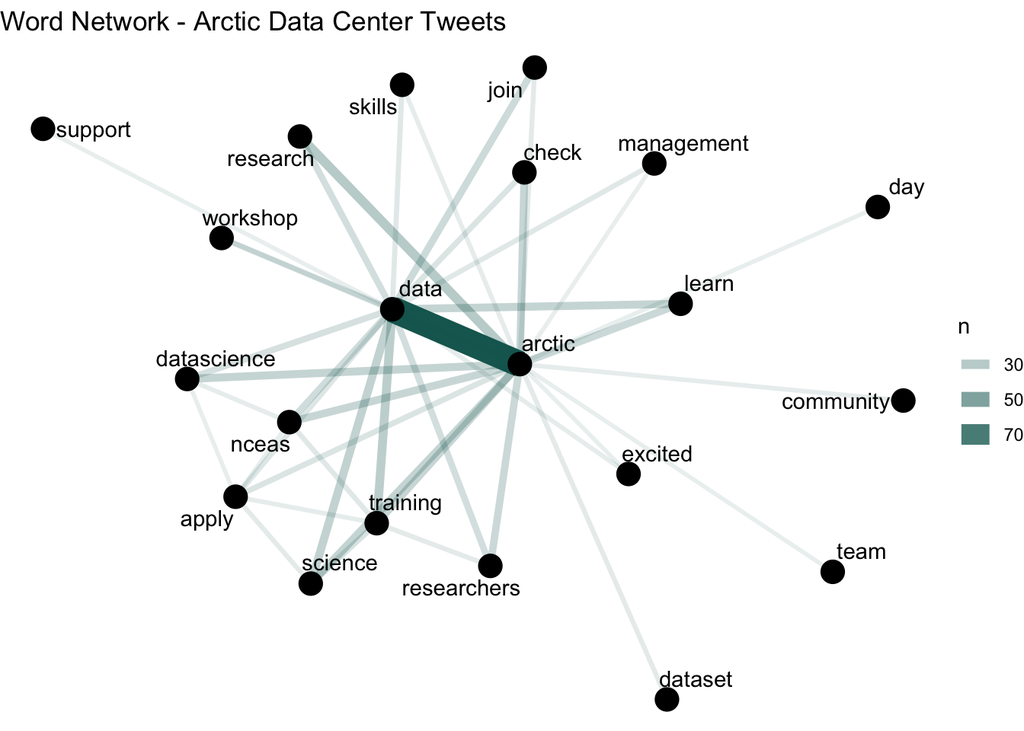